# Analysis of genotype-phenotype associations in BBS

### Patient group within BBSome

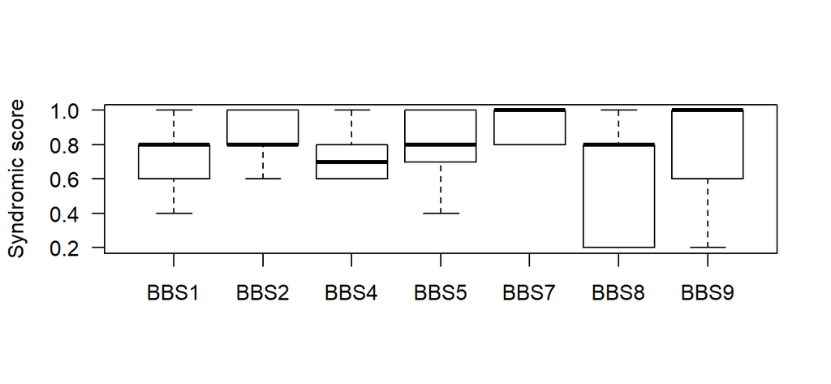

```
##
##  Kruskal-Wallis rank sum test
##
## data:  subset_sscore_cLOF_bbsome_wobbs18$si by subset_sscore_cLOF_bbsome_wobbs18$gene
## Kruskal-Wallis chi-squared = 17.277, df = 6, p-value = 0.008318
```

```
##     Comparison           Z     P.unadj     P.adj
## 1  BBS1 - BBS2 -2.45084259 0.014252227 0.2422879
## 2  BBS1 - BBS4  0.19069936 0.848761143 1.0000000
## 3  BBS2 - BBS4  2.31835041 0.020430285 0.3268846
## 4  BBS1 - BBS5 -1.50092181 0.133375787 1.0000000
## 5  BBS2 - BBS5  0.49729479 0.618981182 1.0000000
## 6  BBS4 - BBS5 -1.51045556 0.130927222 1.0000000
## 7  BBS1 - BBS7 -2.62886303 0.008567086 0.1713417
## 8  BBS2 - BBS7 -0.73960479 0.459539836 1.0000000
## 9  BBS4 - BBS7 -2.56609072 0.010285192 0.1954187
## 10 BBS5 - BBS7 -1.08503112 0.277907873 1.0000000
## 11 BBS1 - BBS8  0.93911447 0.347671975 1.0000000
## 12 BBS2 - BBS8  2.56421355 0.010340990 0.1861378
## 13 BBS4 - BBS8  0.73772762 0.460679985 1.0000000
## 14 BBS5 - BBS8  1.92229923 0.054568117 0.8185218
## 15 BBS7 - BBS8  2.81309995 0.004906640 0.1030394
## 16 BBS1 - BBS9 -1.49527431 0.134842867 1.0000000
## 17 BBS2 - BBS9  0.55606383 0.578167219 1.0000000
## 18 BBS4 - BBS9 -1.50176280 0.133158380 1.0000000
## 19 BBS5 - BBS9  0.04126293 0.967086287 0.9670863
## 20 BBS7 - BBS9  1.14146434 0.253676745 1.0000000
## 21 BBS8 - BBS9 -1.91669773 0.055276344 0.7738688
```

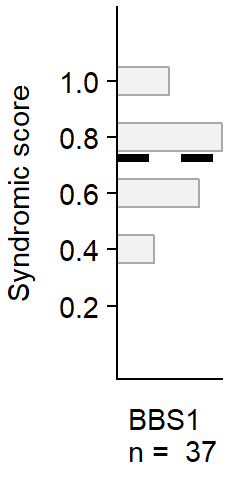

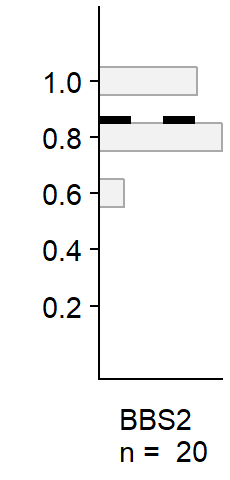

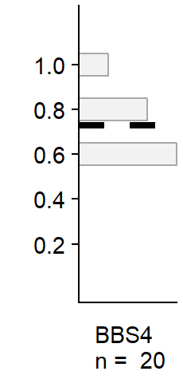

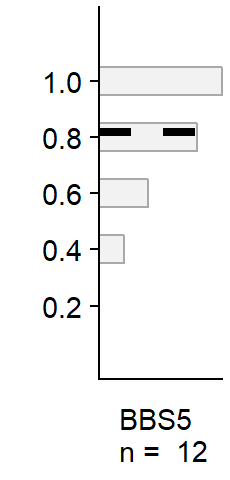

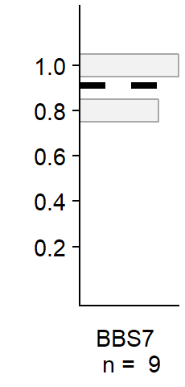

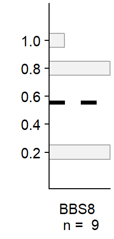

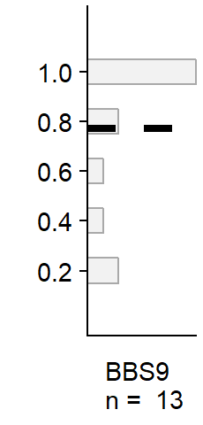

### Missense and cLOF mutations in patient groups

Here, we test if the severity score differs between patients with missense or cLOF mutations in distinct groups of patients. These figures are used for `Figure S4`.

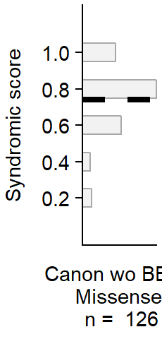

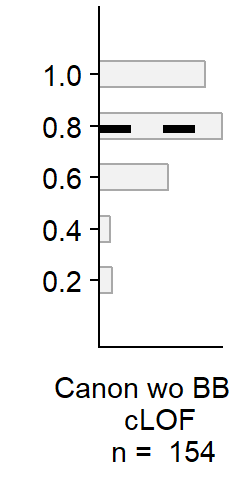

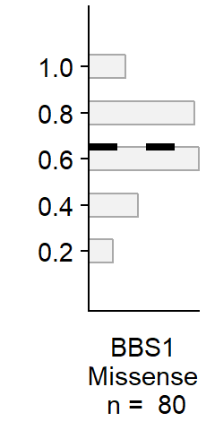

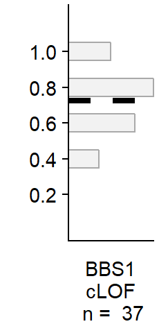

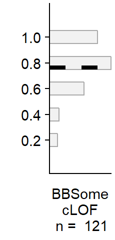

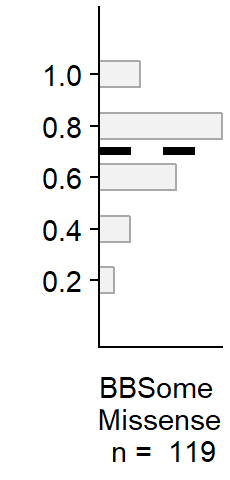

```
##
##  Wilcoxon rank sum test with continuity correction
##
## data:  subset_sscore_cLOF_canonwobbs1$si and subset_sscore_MS_canonwobbs1$si
## W = 10976, p-value = 0.04593
## alternative hypothesis: true location shift is not equal to 0
```

```
##
##  Fisher's Exact Test for Count Data
##
## data:
## p-value = 0.0224
## alternative hypothesis: true odds ratio is not equal to 1
## 95 percent confidence interval:
##  1.068584 3.436947
## sample estimates:
## odds ratio
##   1.900091
```

```
##
##  Wilcoxon rank sum test with continuity correction
##
## data:  subset_sscore_cLOF_bbs1$si and subset_sscore_MS_bbs1$si
## W = 1747, p-value = 0.1034
## alternative hypothesis: true location shift is not equal to 0
```

```
##
##  Fisher's Exact Test for Count Data
##
## data:
## p-value = 0.2637
## alternative hypothesis: true odds ratio is not equal to 1
## 95 percent confidence interval:
##  0.5271485 6.1219836
## sample estimates:
## odds ratio
##   1.830508
```

```
##
##  Wilcoxon rank sum test with continuity correction
##
## data:  subset_sscore_cLOF_bbsome$si and subset_sscore_MS_bbsome$si
## W = 8512.5, p-value = 0.01044
## alternative hypothesis: true location shift is not equal to 0
```

```
##
##  Fisher's Exact Test for Count Data
##
## data:
## p-value = 0.004894
## alternative hypothesis: true odds ratio is not equal to 1
## 95 percent confidence interval:
##  1.280853 5.166578
## sample estimates:
## odds ratio
##   2.531345
```

Below, we visualize the percentage of cLOF mutations in BBSome patients with syndromic score = 1 according to mutations in different BBS genes.

|  | per_MS | per_cLOF |
| --- | --- | --- |
| BBS1 | 11.25 | 18.92 |
| BBS2 | 15.38 | 40.00 |
| BBS4 | 0.00 | 15.00 |
| BBS5 | 0.00 | 41.67 |
| BBS7 | 33.33 | 55.56 |
| BBS8 | 0.00 | 11.11 |
| BBS9 | NaN | 53.85 |

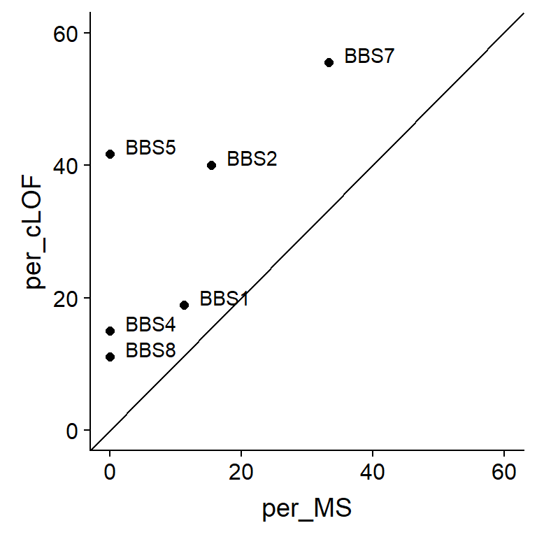

# Analysis of phenotypes

For this analysis, all available data were used, i.e. not restricted to the ’set. Statistical significance of penetrance of phenotypes was tested using Fisher test.

### Phenotypes in gene groups:

First, let’s test if any differences in the penetrance of phenotypes exist between gene groups in each phenotype.

On the 5% level, differences were shown in PD, CI, REP, REN and HEART.

Let’have a look at the differences between individual groups to reveal which differences account for the overall difference. As there are 3 groups, the p-value on which we consider the difference being statistical significance will be lowered according to Sidak correction for multiple comparisons.

Symbol

Orig. p-value

Sidak p-value

#

< 0.1

< 3.45e-02

< 0.05

< 1.70e-02

< 0.01

< 3.34e-03

***

< 0.001

< 3.33e-04

< 1e-04

< 3.33e-05

data1

data2

phenotype

p_val

sidak

subset_bbsome

subset_allwow

PD

0.0136416

subset_bbs3

subset_allwow

PD

0.3973247

subset_chaperonins

subset_allwow

PD

0.0015220

subset_bbsome

subset_allwow

CI

0.0388899

subset_bbs3

subset_allwow

CI

0.0000000

subset_chaperonins

subset_allwow

CI

0.1344585

subset_bbsome

subset_allwow

REP

0.4799351

subset_bbs3

subset_allwow

REP

0.0008108

subset_chaperonins

subset_allwow

REP

0.0156287

subset_bbsome

subset_allwow

REN

0.0458611

subset_bbs3

subset_allwow

REN

0.0000407

***

subset_chaperonins

subset_allwow

REN

0.0000356

***

subset_bbsome

subset_allwow

HEART

0.7639123

subset_bbs3

subset_allwow

HEART

0.0018643

subset_chaperonins

subset_allwow

HEART

0.1031235

Generate charts:

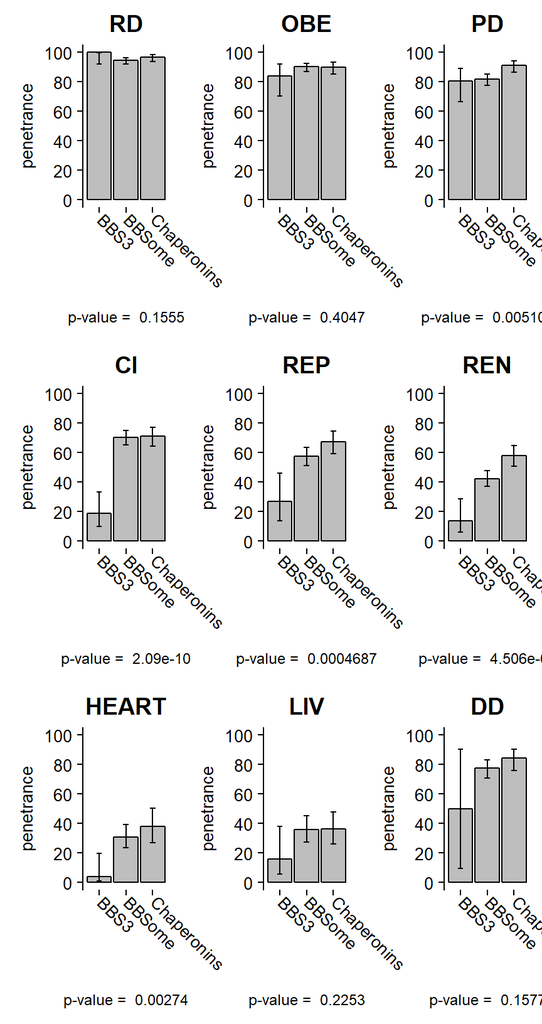

| count |
| --- |
| RD - 45, 438, 233 |
| OBE - 44, 420, 230 |
| PD - 46, 403, 204 |
| CI - 42, 352, 192 |
| REP - 26, 254, 141 |
| REN - 36, 316, 193 |
| HEART - 25, 130, 63 |
| LIV - 19, 109, 72 |
| DD - 2, 165, 96 |

### Phenotypes in chaperonins:

```
## [1] "RD 0.0971091617970856"
## [1] "OBE 0.287061851678097"
## [1] "PD 0.542626188133288"
## [1] "CI 0.0720671619238044"
## [1] "REP 0.460461570441896"
## [1] "REN 0.0383252422323136"
## [1] "HEART 0.161565855118702"
## [1] "LIV 0.743735181014476"
## [1] "DD 0.000215201592725981"
```

Let’have a look at the differences between individual groups to reveal which differences account for the overall difference. We can use the same Sidak values as before:

Symbol

Orig. p-value

Sidak p-value

#

< 0.1

< 3.45e-02

< 0.05

< 1.70e-02

< 0.01

< 3.34e-03

***

< 0.001

< 3.33e-04

< 1e-04

< 3.33e-05

| data1 | data2 | phenotype | p_val | sidak |
| --- | --- | --- | --- | --- |
| subset_bbs6 | subset_chaperonins | DD | 0.0028753 | ** |
| subset_bbs10 | subset_chaperonins | DD | 0.0006079 | ** |
| subset_bbs12 | subset_chaperonins | DD | 0.3592457 |  |

Generate charts:

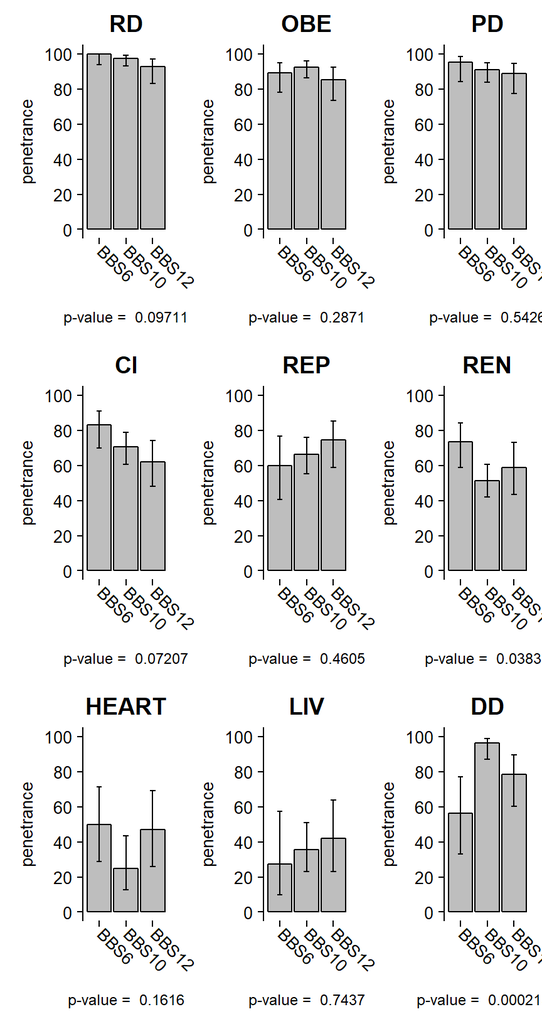

| count |
| --- |
| RD - 56, 121, 56 |
| OBE - 55, 121, 54 |
| PD - 42, 109, 53 |
| CI - 47, 95, 50 |
| REP - 25, 77, 39 |
| REN - 45, 109, 39 |
| HEART - 18, 28, 17 |
| LIV - 11, 42, 19 |
| DD - 16, 52, 28 |

### Phenotypes in bbsome:

```
## [1] "RD 0.562721710987549"
## [1] "OBE 0.00439397649463654"
## [1] "PD 2.26805747902236e-05"
## [1] "CI 0.0046076968229111"
## [1] "REP 0.000247603921541537"
## [1] "REN 3.61642755658095e-07"
## [1] "HEART 0.0021865934443242"
## [1] "LIV 1.78364848188682e-05"
## [1] "DD 0.00507256068782554"
```

On the 5% level, differences were shown in OBE, PD, CI, REP, REN, HEART, LIV and DD.

Let’have a look at the differences between individual groups to reveal which differences account for the overall difference. We will use the following Sidak values for multiple comparison correction:

Symbol

Orig. p-value

Sidak p-value

#

< 0.1

< 1.49e-02

< 0.05

< 7.30e-03

< 0.01

< 1.43e-03

***

< 0.001

< 1.43e-04

< 1e-04

< 1.43e-05

data1

data2

phenotype

p_val

sidak

subset_bbs1

subset_bbsome_wobbs18

OBE

0.0076490

#

subset_bbs2

subset_bbsome_wobbs18

OBE

0.0279320

subset_bbs4

subset_bbsome_wobbs18

OBE

0.0675369

subset_bbs5

subset_bbsome_wobbs18

OBE

0.5280963

subset_bbs7

subset_bbsome_wobbs18

OBE

0.1560526

subset_bbs8

subset_bbsome_wobbs18

OBE

0.0734249

subset_bbs9

subset_bbsome_wobbs18

OBE

1.0000000

subset_bbs1

subset_bbsome_wobbs18

PD

0.0000134

subset_bbs2

subset_bbsome_wobbs18

PD

0.0000205

***

subset_bbs4

subset_bbsome_wobbs18

PD

0.3007947

subset_bbs5

subset_bbsome_wobbs18

PD

0.7946220

subset_bbs7

subset_bbsome_wobbs18

PD

0.6509235

subset_bbs8

subset_bbsome_wobbs18

PD

0.3215659

subset_bbs9

subset_bbsome_wobbs18

PD

0.3979942

subset_bbs1

subset_bbsome_wobbs18

CI

0.0191541

subset_bbs2

subset_bbsome_wobbs18

CI

0.1886035

subset_bbs4

subset_bbsome_wobbs18

CI

0.4052588

subset_bbs5

subset_bbsome_wobbs18

CI

0.1716368

subset_bbs7

subset_bbsome_wobbs18

CI

0.0017845

subset_bbs8

subset_bbsome_wobbs18

CI

0.5657415

subset_bbs9

subset_bbsome_wobbs18

CI

0.4281109

subset_bbs1

subset_bbsome_wobbs18

REP

0.0000020

subset_bbs2

subset_bbsome_wobbs18

REP

0.2221041

subset_bbs4

subset_bbsome_wobbs18

REP

0.2328889

subset_bbs5

subset_bbsome_wobbs18

REP

0.2494720

subset_bbs7

subset_bbsome_wobbs18

REP

0.0376636

subset_bbs8

subset_bbsome_wobbs18

REP

0.0831311

subset_bbs9

subset_bbsome_wobbs18

REP

1.0000000

subset_bbs1

subset_bbsome_wobbs18

REN

0.0000902

***

subset_bbs2

subset_bbsome_wobbs18

REN

0.0000180

***

subset_bbs4

subset_bbsome_wobbs18

REN

0.0169164

subset_bbs5

subset_bbsome_wobbs18

REN

0.5049661

subset_bbs7

subset_bbsome_wobbs18

REN

0.1298024

subset_bbs8

subset_bbsome_wobbs18

REN

0.1650302

subset_bbs9

subset_bbsome_wobbs18

REN

0.0467872

subset_bbs1

subset_bbsome_wobbs18

HEART

0.0340880

subset_bbs2

subset_bbsome_wobbs18

HEART

0.0001252

***

subset_bbs4

subset_bbsome_wobbs18

HEART

0.7608575

subset_bbs5

subset_bbsome_wobbs18

HEART

1.0000000

subset_bbs7

subset_bbsome_wobbs18

HEART

1.0000000

subset_bbs8

subset_bbsome_wobbs18

HEART

1.0000000

subset_bbs9

subset_bbsome_wobbs18

HEART

0.4336469

subset_bbs1

subset_bbsome_wobbs18

LIV

0.0694845

subset_bbs2

subset_bbsome_wobbs18

LIV

0.0237358

subset_bbs4

subset_bbsome_wobbs18

LIV

0.0098775

#

subset_bbs5

subset_bbsome_wobbs18

LIV

0.0003628

subset_bbs7

subset_bbsome_wobbs18

LIV

0.3714896

subset_bbs8

subset_bbsome_wobbs18

LIV

0.1297768

subset_bbs9

subset_bbsome_wobbs18

LIV

0.7522100

subset_bbs1

subset_bbsome_wobbs18

DD

0.0020130

subset_bbs2

subset_bbsome_wobbs18

DD

0.3751534

subset_bbs4

subset_bbsome_wobbs18

DD

0.7353014

subset_bbs5

subset_bbsome_wobbs18

DD

0.2083286

subset_bbs7

subset_bbsome_wobbs18

DD

0.0412148

subset_bbs8

subset_bbsome_wobbs18

DD

0.1075481

subset_bbs9

subset_bbsome_wobbs18

DD

0.3012481

Generate charts:

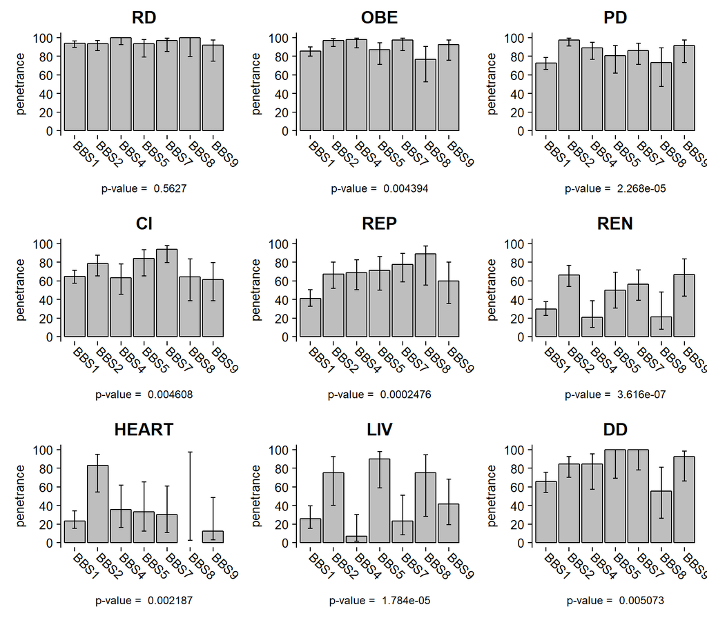

| count |
| --- |
| RD - 208, 79, 45, 31, 34, 15, 25 |
| OBE - 190, 71, 47, 31, 37, 17, 26 |
| PD - 180, 77, 45, 26, 36, 15, 23 |
| CI - 181, 51, 30, 25, 32, 14, 18 |
| REP - 112, 40, 29, 21, 27, 9, 15 |
| REN - 135, 65, 29, 22, 32, 14, 18 |
| HEART - 77, 12, 14, 9, 10, 0, 8 |
| LIV - 47, 8, 15, 10, 13, 4, 12 |
| DD - 67, 39, 13, 9, 14, 9, 13 |

## Analysis of cLOF subset

For this analysis, all available data were used, i.e. not restricted to the ’set. However, only patients having causative mutation of type cLOF were included. Statistical significance of penetrance of phenotypes was tested using Fisher test.

### Phenotypes in gene groups:

First, let’s test if any differences in phenotype penetrance exist between all groups.

```
## [1] "RD 0.999999999999259"
## [1] "OBE 0.917829039328025"
## [1] "PD 0.401349570081445"
## [1] "CI 0.01403740441853"
## [1] "REP 0.367342571927213"
## [1] "REN 0.0108284198252536"
## [1] "HEART 0.358575285247928"
## [1] "LIV 0.897447277608471"
## [1] "DD 0.327317804449542"
```

On the 5% level, differences were shown in CI and REN.

Let’have a look at the differences between individual groups to reveal which differences account for the overall difference. As there are 3 groups, the p-value on which we consider the difference being statistical significance will be lowered according to Sidak correction for multiple comparisons.

Symbol

Orig. p-value

Sidak p-value

#

< 0.1

< 3.45e-02

< 0.05

< 1.70e-02

< 0.01

< 3.34e-03

***

< 0.001

< 3.33e-04

< 1e-04

< 3.33e-05

| data1 | data2 | phenotype | p_val | sidak |
| --- | --- | --- | --- | --- |
| subset_cLOF_bbsome | subset_cLOF_allwow | CI | 0.0007480 | ** |
| subset_cLOF_bbs3 | subset_cLOF_allwow | CI | 0.0359204 |  |
| subset_cLOF_chaperonins | subset_cLOF_allwow | CI | 0.1755968 |  |
| subset_cLOF_bbsome | subset_cLOF_allwow | REN | 0.2973654 |  |
| subset_cLOF_bbs3 | subset_cLOF_allwow | REN | 0.0241660 | # |
| subset_cLOF_chaperonins | subset_cLOF_allwow | REN | 0.0191525 | # |

Generate charts:

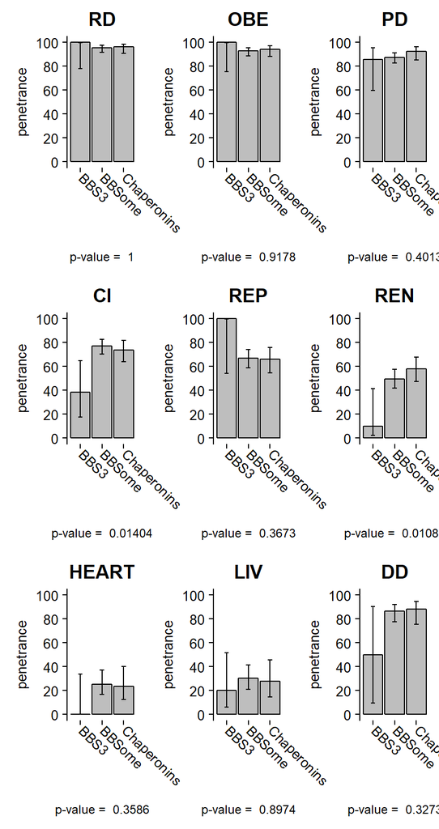

| count |
| --- |
| RD - 14, 220, 107 |
| OBE - 12, 222, 105 |
| PD - 14, 218, 92 |
| CI - 13, 175, 88 |
| REP - 5, 140, 71 |
| REN - 10, 157, 88 |
| HEART - 8, 67, 34 |
| LIV - 10, 73, 29 |
| DD - 2, 82, 43 |

### Phenotypes in chaperonins:

```
## [1] "RD 0.00742373479104205"
## [1] "OBE 0.0921968210527379"
## [1] "PD 0.79941434430418"
## [1] "CI 0.105712311304585"
## [1] "REP 0.921023325372066"
## [1] "REN 0.0112168482399508"
## [1] "HEART 0.0168524213541555"
## [1] "LIV 0.220220658901323"
## [1] "DD 0.00207978823974283"
```

Let’have a look at the differences between individual groups to reveal which differences account for the overall difference. We can use the same Sidak values as before:

Symbol

Orig. p-value

Sidak p-value

#

< 0.1

< 3.45e-02

< 0.05

< 1.70e-02

< 0.01

< 3.34e-03

***

< 0.001

< 3.33e-04

< 1e-04

< 3.33e-05

data1

data2

phenotype

p_val

sidak

subset_cLOF_bbs6

subset_cLOF_chaperonins

RD

1.0000000

subset_cLOF_bbs10

subset_cLOF_chaperonins

RD

0.0263052

#

subset_cLOF_bbs12

subset_cLOF_chaperonins

RD

0.0046024

subset_cLOF_bbs6

subset_cLOF_chaperonins

HEART

0.4206774

subset_cLOF_bbs10

subset_cLOF_chaperonins

HEART

0.0127429

subset_cLOF_bbs12

subset_cLOF_chaperonins

HEART

0.0314456

#

subset_cLOF_bbs6

subset_cLOF_chaperonins

DD

1.0000000

subset_cLOF_bbs10

subset_cLOF_chaperonins

DD

0.0020798

subset_cLOF_bbs12

subset_cLOF_chaperonins

DD

0.0013370

Generate charts:

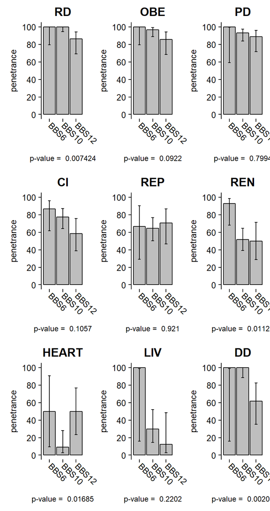

| count |
| --- |
| RD - 15, 63, 29 |
| OBE - 15, 62, 28 |
| PD - 6, 59, 27 |
| CI - 15, 49, 24 |
| REP - 6, 48, 17 |
| REN - 14, 56, 18 |
| HEART - 2, 22, 10 |
| LIV - 1, 20, 8 |
| DD - 1, 29, 13 |

### Phenotypes in bbsome:

```
## [1] "RD 0.376040330718765"
## [1] "OBE 0.0019098572402795"
## [1] "PD 0.00195657711921316"
## [1] "CI 0.0175062526103903"
## [1] "REP 0.90636196911667"
## [1] "REN 8.39134697828311e-05"
## [1] "HEART 0.00544521559816008"
## [1] "LIV 7.33184454853601e-06"
## [1] "DD 0.0780111842131413"
```

On the 5% level, differences were shown in OBE, PD, CI, REN, HEART and LIV.

Let’have a look at the differences between individual groups to reveal which differences account for the overall difference. We will use the following Sidak values for multiple comparison correction:

Symbol

Orig. p-value

Sidak p-value

#

< 0.1

< 1.49e-02

< 0.05

< 7.30e-03

< 0.01

< 1.43e-03

***

< 0.001

< 1.43e-04

< 1e-04

< 1.43e-05

data1

data2

phenotype

p_val

sidak

subset_cLOF_bbs1

subset_cLOF_bbsome_wobbs18

OBE

1.0000000

subset_cLOF_bbs2

subset_cLOF_bbsome_wobbs18

OBE

0.2036425

subset_cLOF_bbs4

subset_cLOF_bbsome_wobbs18

OBE

0.0834036

subset_cLOF_bbs5

subset_cLOF_bbsome_wobbs18

OBE

0.0516248

subset_cLOF_bbs7

subset_cLOF_bbsome_wobbs18

OBE

0.6057670

subset_cLOF_bbs8

subset_cLOF_bbsome_wobbs18

OBE

0.0064705

subset_cLOF_bbs9

subset_cLOF_bbsome_wobbs18

OBE

0.6538055

subset_cLOF_bbs1

subset_cLOF_bbsome_wobbs18

PD

0.0395184

subset_cLOF_bbs2

subset_cLOF_bbsome_wobbs18

PD

0.0017053

subset_cLOF_bbs4

subset_cLOF_bbsome_wobbs18

PD

0.7921455

subset_cLOF_bbs5

subset_cLOF_bbsome_wobbs18

PD

0.4368513

subset_cLOF_bbs7

subset_cLOF_bbsome_wobbs18

PD

0.3739653

subset_cLOF_bbs8

subset_cLOF_bbsome_wobbs18

PD

0.0413264

subset_cLOF_bbs9

subset_cLOF_bbsome_wobbs18

PD

1.0000000

subset_cLOF_bbs1

subset_cLOF_bbsome_wobbs18

CI

0.1369116

subset_cLOF_bbs2

subset_cLOF_bbsome_wobbs18

CI

0.6452013

subset_cLOF_bbs4

subset_cLOF_bbsome_wobbs18

CI

0.0245652

subset_cLOF_bbs5

subset_cLOF_bbsome_wobbs18

CI

0.1252249

subset_cLOF_bbs7

subset_cLOF_bbsome_wobbs18

CI

0.4575274

subset_cLOF_bbs8

subset_cLOF_bbsome_wobbs18

CI

0.1293419

subset_cLOF_bbs9

subset_cLOF_bbsome_wobbs18

CI

0.2078024

subset_cLOF_bbs1

subset_cLOF_bbsome_wobbs18

REN

0.0290684

subset_cLOF_bbs2

subset_cLOF_bbsome_wobbs18

REN

0.0008756

subset_cLOF_bbs4

subset_cLOF_bbsome_wobbs18

REN

0.0011867

subset_cLOF_bbs5

subset_cLOF_bbsome_wobbs18

REN

0.1832407

subset_cLOF_bbs7

subset_cLOF_bbsome_wobbs18

REN

0.3654115

subset_cLOF_bbs8

subset_cLOF_bbsome_wobbs18

REN

0.3278799

subset_cLOF_bbs9

subset_cLOF_bbsome_wobbs18

REN

0.3013681

subset_cLOF_bbs1

subset_cLOF_bbsome_wobbs18

HEART

0.0807465

subset_cLOF_bbs2

subset_cLOF_bbsome_wobbs18

HEART

0.0007339

subset_cLOF_bbs4

subset_cLOF_bbsome_wobbs18

HEART

0.7246881

subset_cLOF_bbs5

subset_cLOF_bbsome_wobbs18

HEART

1.0000000

subset_cLOF_bbs7

subset_cLOF_bbsome_wobbs18

HEART

0.6686576

subset_cLOF_bbs8

subset_cLOF_bbsome_wobbs18

HEART

1.0000000

subset_cLOF_bbs9

subset_cLOF_bbsome_wobbs18

HEART

0.6686576

subset_cLOF_bbs1

subset_cLOF_bbsome_wobbs18

LIV

0.0214694

subset_cLOF_bbs2

subset_cLOF_bbsome_wobbs18

LIV

0.5148402

subset_cLOF_bbs4

subset_cLOF_bbsome_wobbs18

LIV

0.0923700

subset_cLOF_bbs5

subset_cLOF_bbsome_wobbs18

LIV

0.0000238

***

subset_cLOF_bbs7

subset_cLOF_bbsome_wobbs18

LIV

0.6669633

subset_cLOF_bbs8

subset_cLOF_bbsome_wobbs18

LIV

0.0878995

subset_cLOF_bbs9

subset_cLOF_bbsome_wobbs18

LIV

0.4763031

Generate charts:

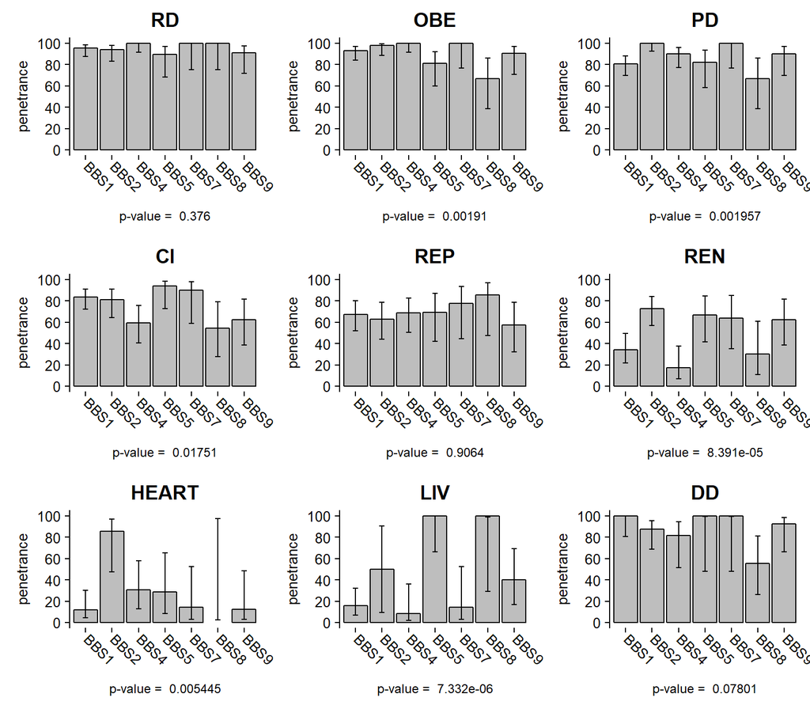

| count |
| --- |
| RD - 66, 48, 40, 19, 12, 12, 22 |
| OBE - 69, 45, 40, 21, 13, 12, 21 |
| PD - 67, 47, 41, 17, 13, 12, 20 |
| CI - 61, 32, 27, 17, 10, 11, 16 |
| REP - 40, 27, 29, 13, 9, 7, 14 |
| REN - 41, 40, 23, 15, 11, 10, 16 |
| HEART - 25, 7, 13, 7, 7, 0, 8 |
| LIV - 32, 2, 12, 8, 7, 2, 10 |
| DD - 16, 24, 11, 4, 4, 9, 13 |

## Testing conclusions for Figure 4

PD: BBS2 more frequent than BBS1

```
## [1] "Fisher test for all mutations, p-value =  7.498e-07"
## [1] "Fisher test for cLOF mutations, p-value =  0.0006695"
```

CI: BBSome more frequent than BBS3

```
## [1] "Fisher test for all mutations, p-value =  1.359e-10"
## [1] "Fisher test for cLOF mutations, p-value =  0.004837"
```

CI: BBS7 more frequent than others

```
## [1] "Fisher test for all mutations, p-value =  0.001782"
## [1] "Fisher test for cLOF mutations, p-value =  0.4582"
```

REN: BBS2,7,9 more frequent than BBS1,4,8

```
## [1] "Fisher test for all mutations, p-value =  1.678e-09"
## [1] "Fisher test for cLOF mutations, p-value =  1.947e-06"
```

REN: BBS2 more frequent than BBS1

```
## [1] "Fisher test for all mutations, p-value =  1.44e-06"
## [1] "Fisher test for cLOF mutations, p-value =  0.000785"
```

REN: BBS10 more frequent than BBS1

```
## [1] "Fisher test for all mutations, p-value =  0.000156"
## [1] "Fisher test for cLOF mutations, p-value =  0.06503"
```

LIV: BBS2 more frequent than BBS1

```
## [1] "Fisher test for all mutations, p-value =  0.01116"
## [1] "Fisher test for cLOF mutations, p-value =  0.3262"
```

LIV: BBS10 more frequent than BBS1

```
## [1] "Fisher test for all mutations, p-value =  0.3586"
## [1] "Fisher test for cLOF mutations, p-value =  0.2989"
```

HEART: BBS2 more frequent than others

```
## [1] "Fisher test for all mutations, p-value =  0.0001252"
## [1] "Fisher test for cLOF mutations, p-value =  0.0007339"
```

LIV: BBS5 more frequent than others

```
## [1] "Fisher test for all mutations, p-value =  0.0003628"
## [1] "Fisher test for cLOF mutations, p-value =  2.379e-05"
```

LIV: others more frequent than BBS4

```
## [1] "Fisher test for all mutations, p-value =  0.009878"
## [1] "Fisher test for cLOF mutations, p-value =  0.09237"
```

```
## [1] "Fisher test for all mutations, p-value =  0.000156"
## [1] "Fisher test for cLOF mutations, p-value =  0.06503"
```

## Testing previously published hypotheses for Table S6

### Brinckman, 2013

CI Fisher’s exact test BBS1 vs BBS10 patients

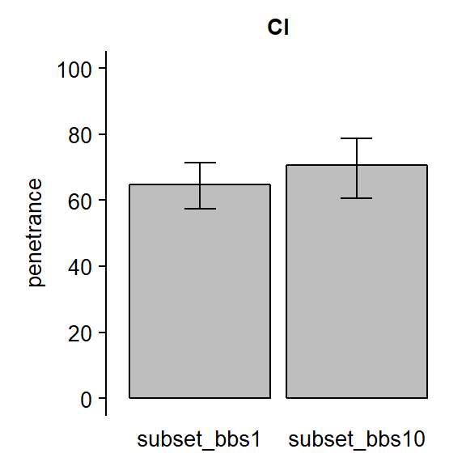

```
## [1] "CI"
## [1] "All mutations"
## [1] 0.1977715
```

### Abu Safieh, 2010

Fisher’s exact test BBS3 vs other canonical genes CI, REP

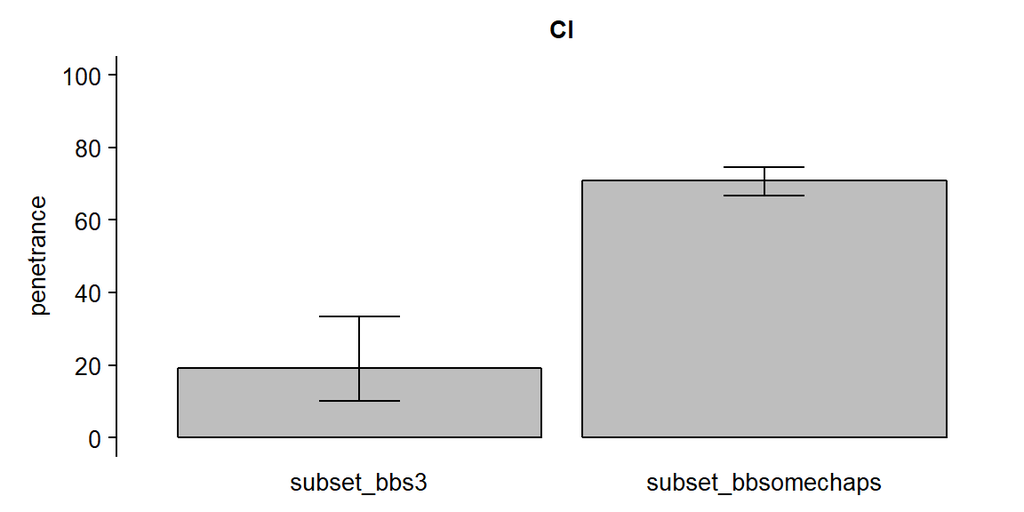

```
## [1] "CI"
## [1] "All mutations"
## [1] 4.042953e-11
```

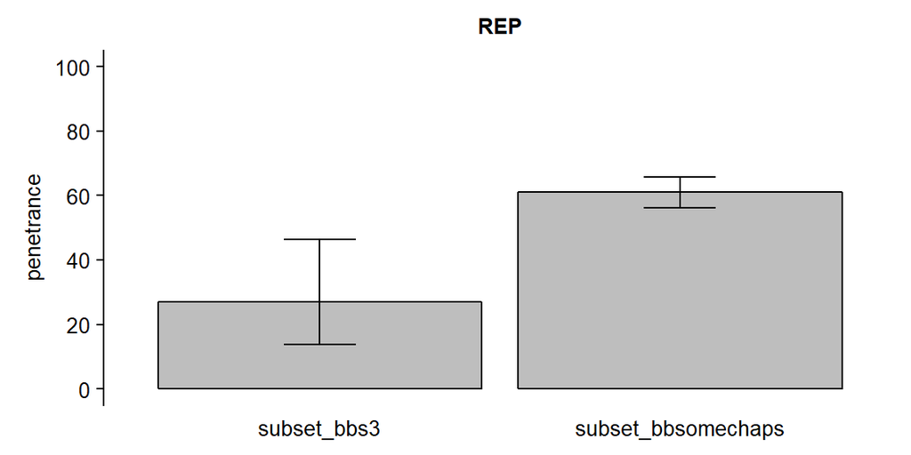

```
## [1] "REP"
## [1] "All mutations"
## [1] 0.0006823322
```

### Billingsley, 2010

all features Kruskal-Wallis test of syndromic score between BBS6, BBS10, BBS12

```
##
##  Kruskal-Wallis rank sum test
##
## data:  subset_sscore_chaperonins$si by subset_sscore_chaperonins$gene
## Kruskal-Wallis chi-squared = 4.0051, df = 2, p-value = 0.135
```

### Castro-Sanchez, 2015

RD, OBE, CI, PD, REP, REN Fisher’s exact test BBS1 vs chaperonins

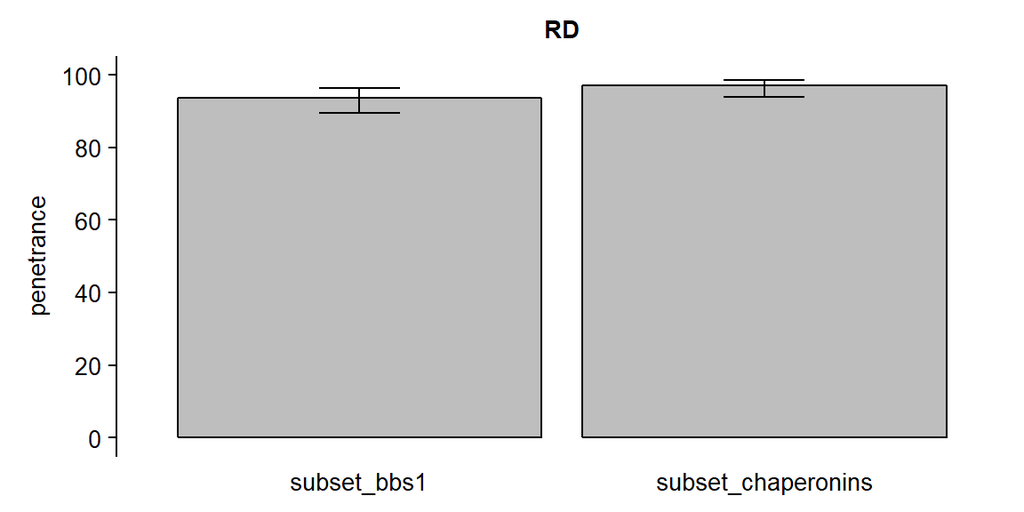

```
## [1] "RD"
## [1] "All mutations"
## [1] 0.07969743
```

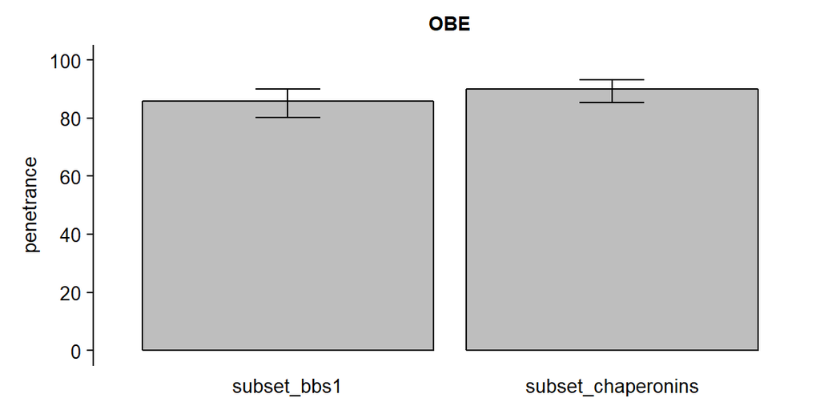

```
## [1] "OBE"
## [1] "All mutations"
## [1] 0.1201889
```

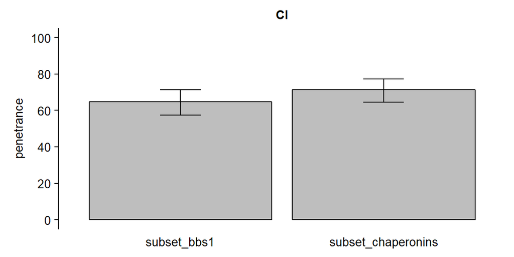

```
## [1] "CI"
## [1] "All mutations"
## [1] 0.1004249
```

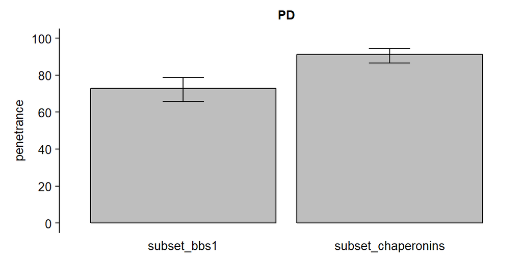

```
## [1] "PD"
## [1] "All mutations"
## [1] 1.642222e-06
```

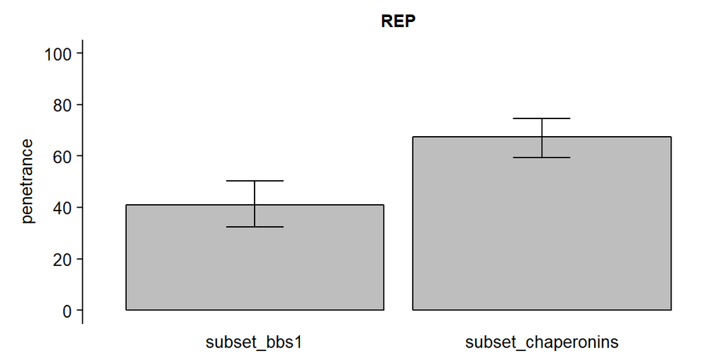

```
## [1] "REP"
## [1] "All mutations"
## [1] 2.342768e-05
```

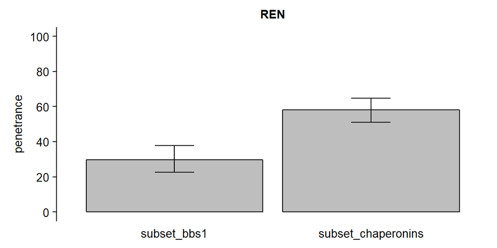

```
## [1] "REN"
## [1] "All mutations"
## [1] 2.693125e-07
```

Fisher’s exact test BBS12 vs BBS1 and BBS10 combined CI

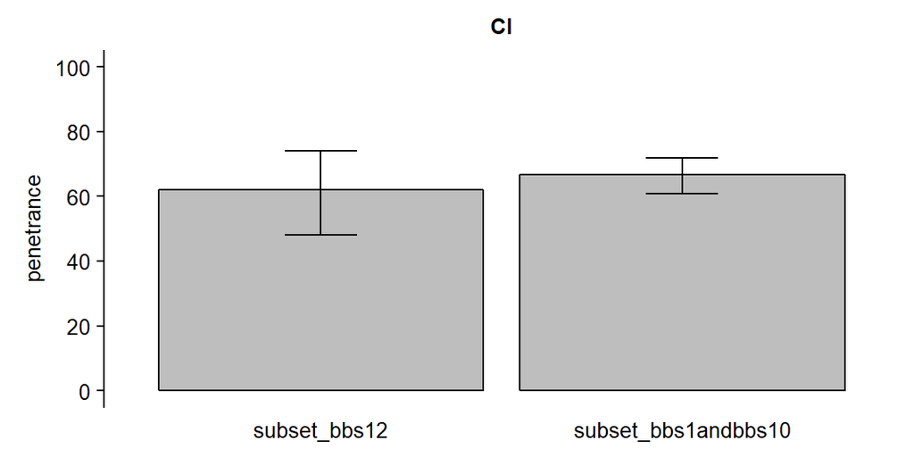

```
## [1] "CI"
## [1] "All mutations"
## [1] 0.3129968
```

### Deveault, 2011

Kruskal-Wallis test of syndromic score between functional classes of canonical genes

```
##
##  Kruskal-Wallis rank sum test
##
## data:  subset_sscore_allwow$si by subset_sscore_allwow$ggroup
## Kruskal-Wallis chi-squared = 21.733, df = 2, p-value = 1.909e-05
```

CI Fisher’s exact test BBS1 vs other canonical BBS genes

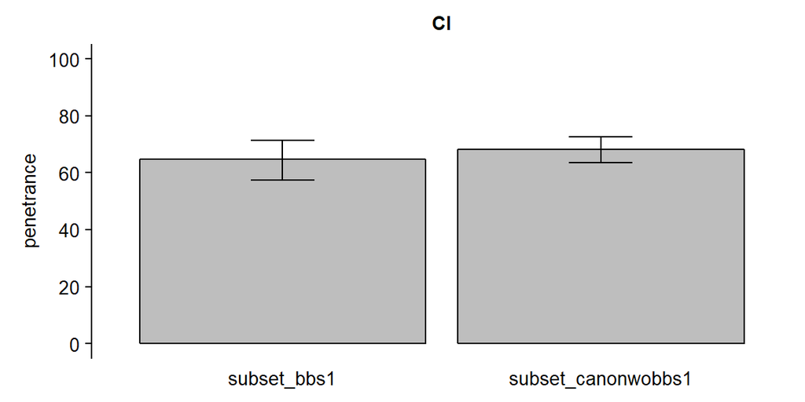

```
## [1] "CI"
## [1] "All mutations"
## [1] 0.2292483
```

Fisher’s exact test BBS12 vs other canonical BBS genes CI

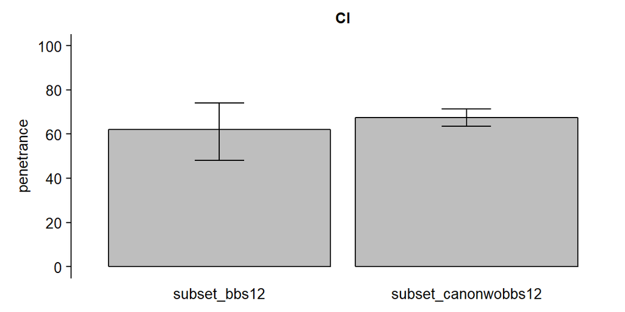

```
## [1] "CI"
## [1] "All mutations"
## [1] 0.2585528
```

Fisher’s exact test BBS10 vs other canonical BBS genes REN

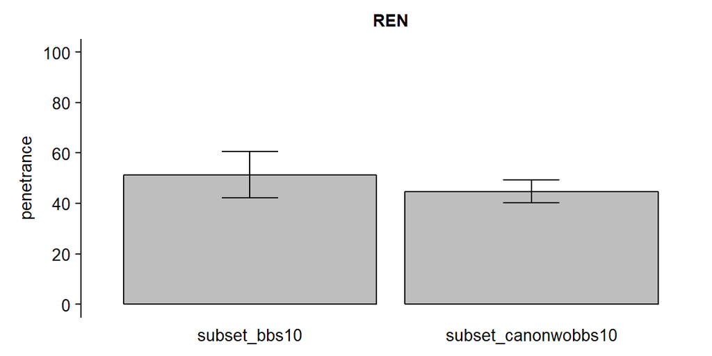

```
## [1] "REN"
## [1] "All mutations"
## [1] 0.1274868
```

### Esposito, 2017

RD Fisher’s exact test BBS10 vs BBS1 and BBS2 patients

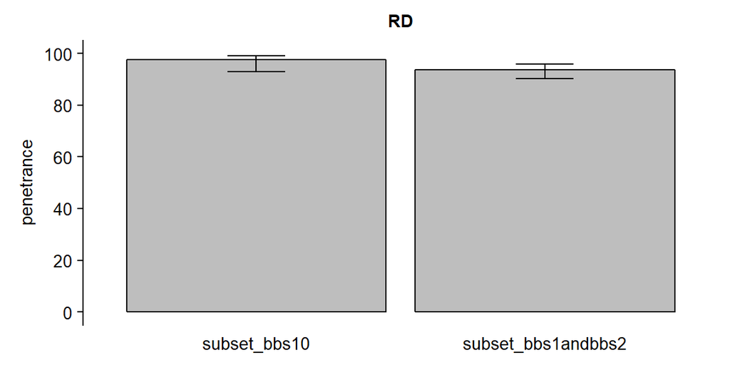

```
## [1] "RD"
## [1] "All mutations"
## [1] 0.08516166
```

REN Fisher’s exact test BBS10 vs BBS1 and BBS2 patients

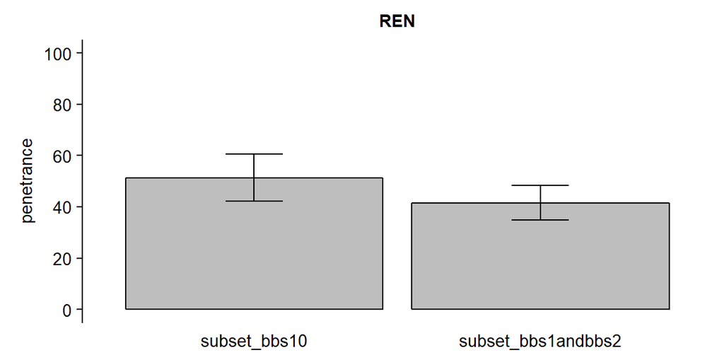

```
## [1] "REN"
## [1] "All mutations"
## [1] 0.06093154
```

### Forsythe, 2015

REN, LIV Fisher’s exact test BBS10 vs BBS1

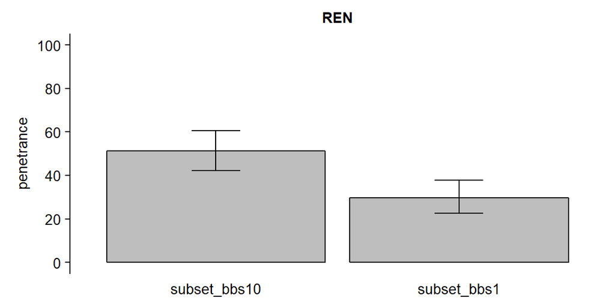

```
## [1] "REN"
## [1] "All mutations"
## [1] 0.0004356552
```

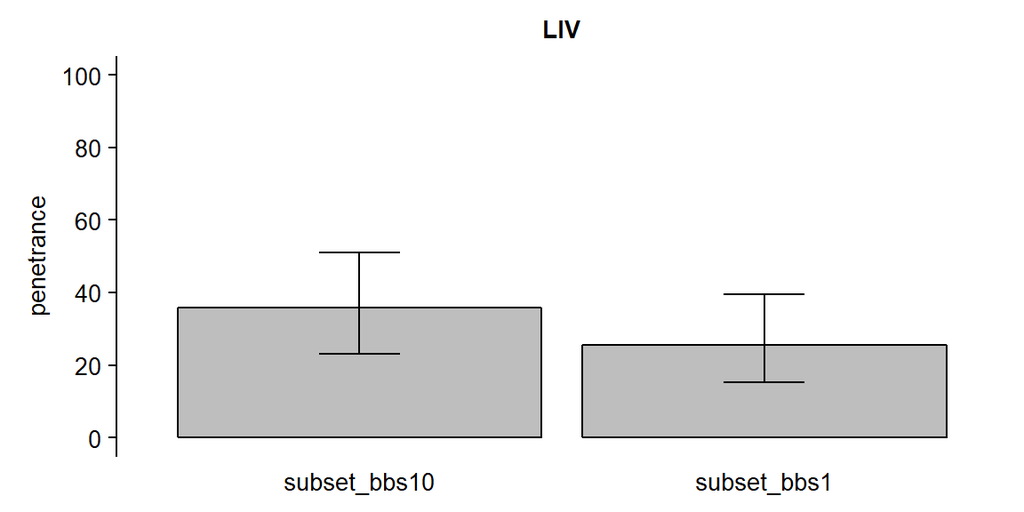

```
## [1] "LIV"
## [1] "All mutations"
## [1] 0.2083269
```

REN, LIV Fisher’s exact test BBS1 and BBS10 MS/MS vs. TR/TR

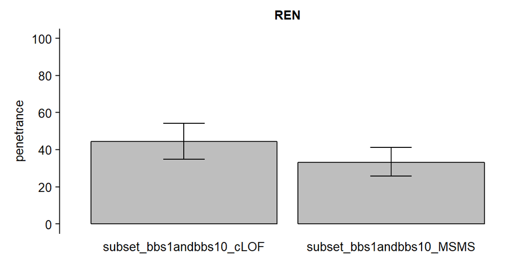

```
## [1] "REN"
## [1] "All mutations"
## [1] 0.05327259
```

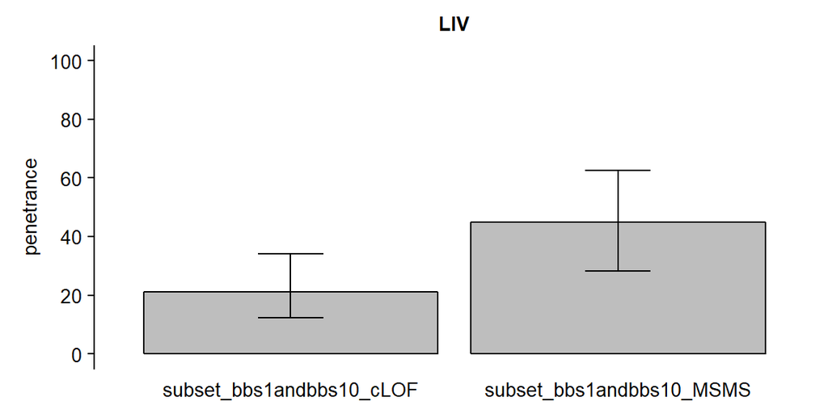

```
## [1] "LIV"
## [1] "All mutations"
## [1] 0.0245949
```

### Forsythe, 2017

REN Fisher’s exact test BBS2, BBS10 and BBS12 vs other canonical

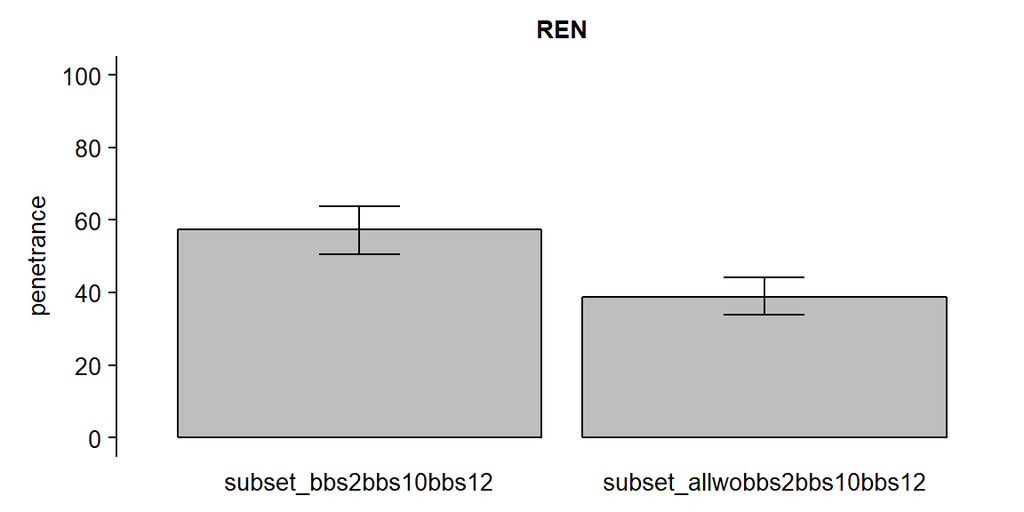

```
## [1] "REN"
## [1] "All mutations"
## [1] 1.845396e-05
```

REN Fisher’s exact test all canonical MS/MS vs. TR/TR

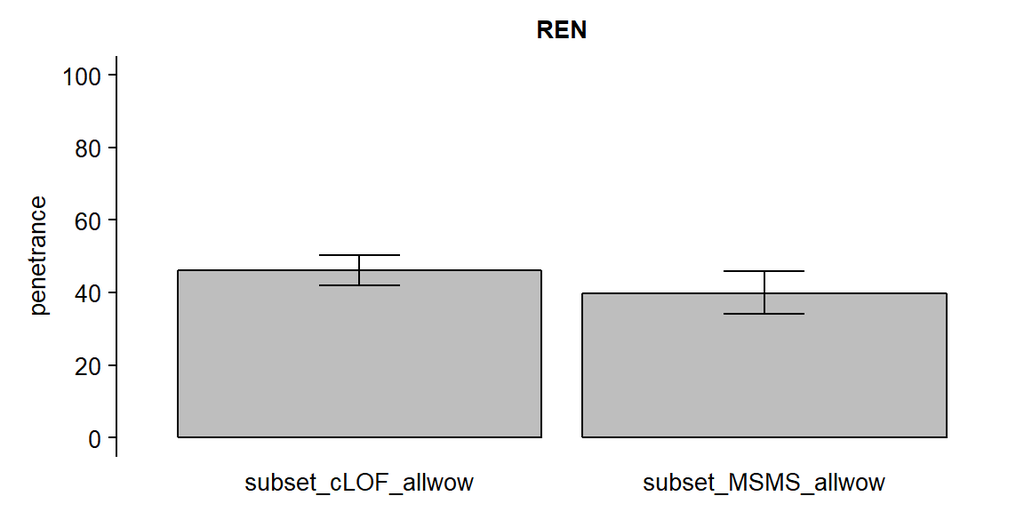

```
## [1] "REN"
## [1] "All mutations"
## [1] 0.05619514
```

REN Fisher’s exact test BBS1 M390R hom vs. BBS1 MS/TR+TR/TR

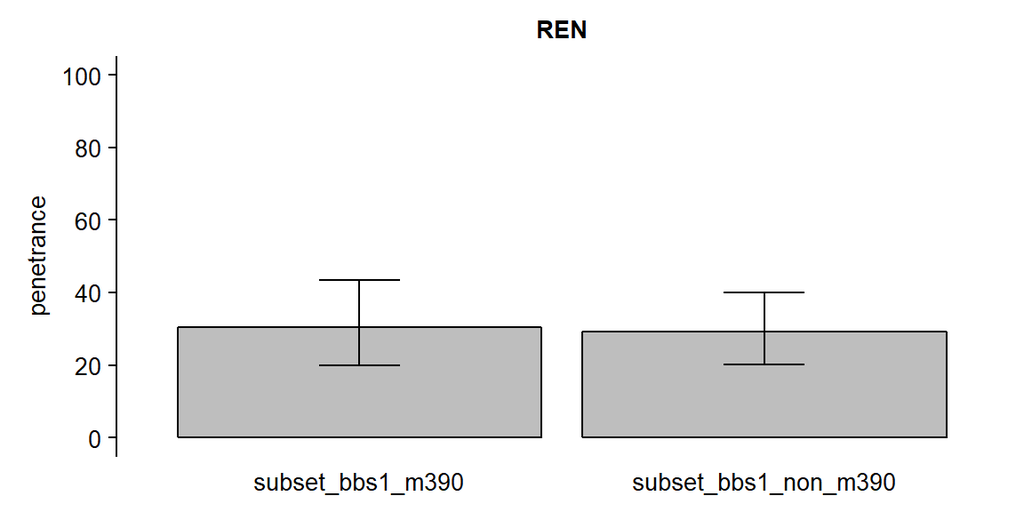

```
## [1] "REN"
## [1] "All mutations"
## [1] 0.6370972
```

### Hjorsthoj, 2010

overall severity Mann-Whitney syndromic score BBS1 vs BBS2 and BBS10

```
## [1] "Wilcoxon test on syndromic score p-value =  8.5327060255974e-05"
```

Mann-Whitney syndromic score BBS1 without patients with M390R vs BBS2 and BBS10

```
## [1] "Wilcoxon test on syndromic score p-value =  0.000939797588702953"
```

REN, CI, OBE, REP Fisher’s exact test BBS1 vs BBS2 and BBS10

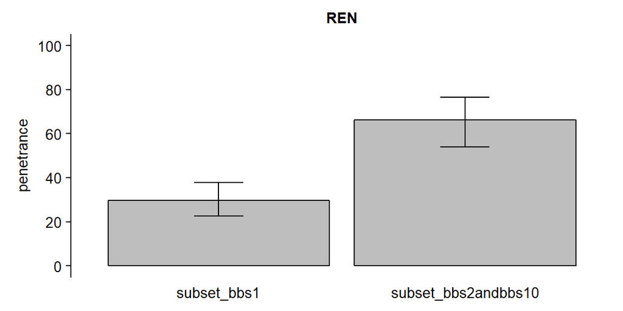

```
## [1] "REN"
## [1] "All mutations"
## [1] 9.664962e-07
```

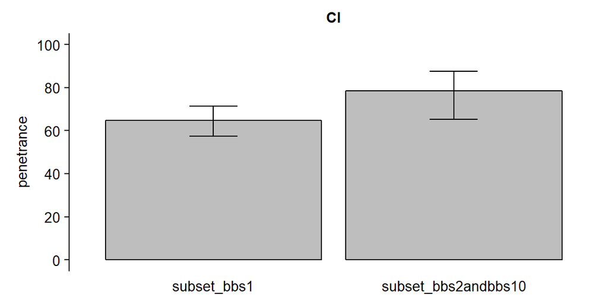

```
## [1] "CI"
## [1] "All mutations"
## [1] 0.04299097
```

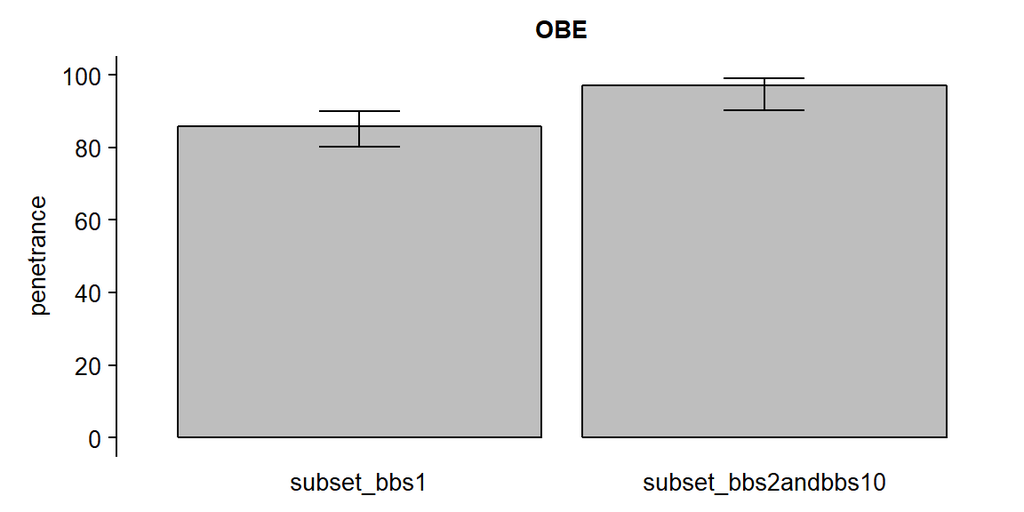

```
## [1] "OBE"
## [1] "All mutations"
## [1] 0.004780513
```

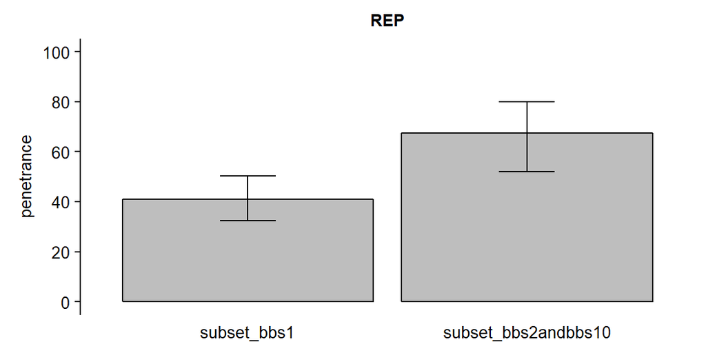

```
## [1] "REP"
## [1] "All mutations"
## [1] 0.003462299
```

### Kerr, 2015

CI Fisher’s exact test BBS1 vs BBS10 vs other canonical (three groups)

```
## [1] "Fisher test all mutations (three groups) p-value =  0.61767336992985"
```

### Pawlik, 2010

overall severity Mann-Whitney syndromic score BBS12 vs other canonical

```
## [1] "Wilcoxon test on syndromic score p-value =  0.80702087932623"
```

### Schaefer, 2011a

PD, REN Fisher’s exact test BBS16 vs all canonical

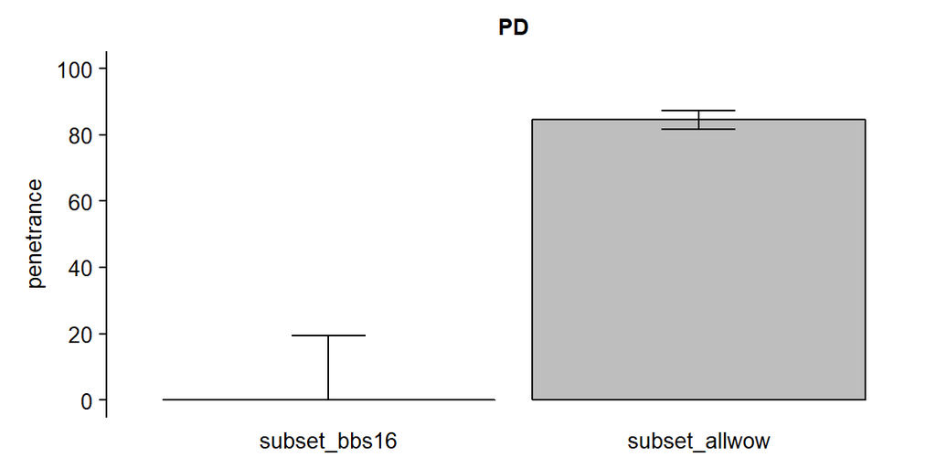

```
## [1] "PD"
## [1] "All mutations"
## [1] 2.705735e-13
```

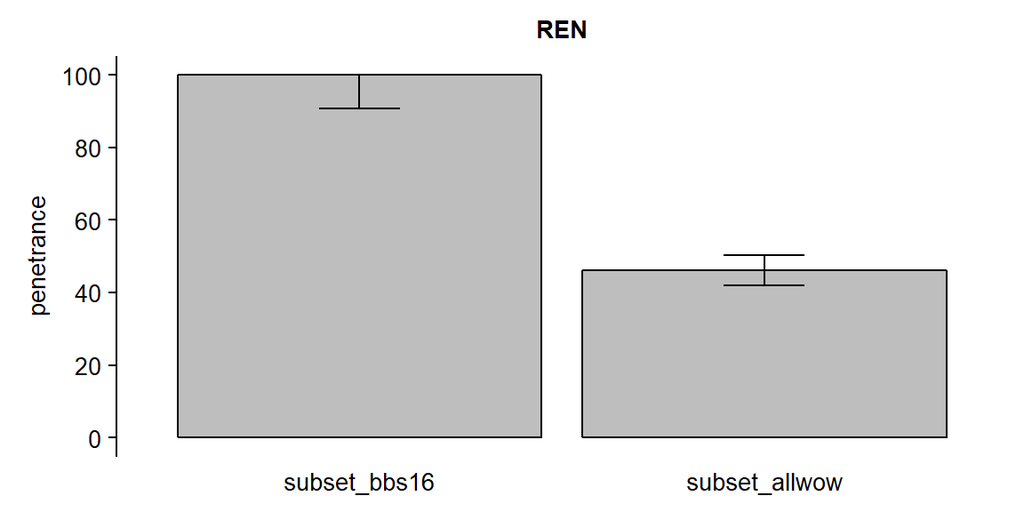

```
## [1] "REN"
## [1] "All mutations"
## [1] 1.423741e-12
```